# Party Identification and the Leaner Problem

One coding decision, and the most repeated number in American politics moves by a factor of five

Democracy’s Data

Last updated September 13, 2026 at 10:53a EDT

*A third of Americans are independents.* You have read that sentence. It is printed every election cycle, in every outlet, usually with a note that the number is at or near a record. This brief asks the question the sentence skips: how many Americans really are independents?

In the 2024 American National Election Study, the share of independents is **6.9%**. It is also **33.0%**. Both numbers come from the same column of the same file, counted over the same respondents. They differ by a factor of 4.8, and the difference is one decision that the sentence never mentions.

## The test

The measure is party identification from the ANES Time Series Cumulative Data File, 1952–2024, obtained from the [American National Election Studies](https://electionstudies.org/data-center/anes-time-series-cumulative-data-file/). The question has been asked in the same form in every study since 1952 — 32 studies, every presidential year and most midterms. The ANES chapter introduces the file and how to read it against its codebook; this brief pulls one question out of it.

This source fits the question because no other kind of source can hold it. Partisanship is not an administrative fact: nobody registers as a “weak Democrat,” and in most states nobody registers as anything at all. It exists only as something people say about themselves, which means it exists only in surveys. And unlike a poll about a vote, no election ever comes along to grade the answer, so the survey’s design decisions are not a layer over the measurement — they *are* the measurement. A seventy-two-year series on one question exists only because ANES staff kept asking the same words, decade after decade, and reconciled the coding so that one column means one thing throughout.

The test comes in two parts. First, count the independents under each defensible reading of the question and see how far apart the counts land. Second, use the fact that the same file records how each person voted, so the disputed group can be watched rather than argued about.

## The data

The cumulative file is one table: one row per interview, with every question that survived reconciliation carried as a column labelled with a VCF number, the file’s own name for a question. This brief reads three of those columns, plus one it deliberately leaves alone. `VCF0301` is the seven-point party identification. `VCF0303` is the file’s own three-category collapse of it. `VCF0704` is the two-party presidential vote, coded 1 for the Democrat and 2 for the Republican. `VCF0009z` is the weight, which counts some answers more than others to make the sample look like the country, and it sits in the file unused here.

`VCF0301` has seven values and looks like a seven-point scale. It is not a scale. It is the record of a branching interview.

```
VCF0301 looks like one column. It is three questions.

  Q1  Generally speaking, do you usually think of yourself as a
      Republican, a Democrat, an Independent, or what?

  Q2  (if Republican or Democrat) Would you call yourself a STRONG
      [R/D] or a NOT VERY STRONG [R/D]?

  Q3  (if Independent or other) Do you think of yourself as CLOSER
      to the Republican or Democratic party?

The seven points are the answers combined:

  1 strong Dem      2 weak Dem      3 independent-Dem   (leaner)
  4 independent-independent
  5 independent-Rep (leaner)        6 weak Rep          7 strong Rep

Five random rows as they arrive. VCF0303 is the file's own collapse.

year  VCF0301  means  VCF0303
1972  5  Independent-Republican  3
1974  4  Independent-Independent  2
1986  2  Weak Democrat  1
1996  6  Weak Republican  3
2016  1  Strong Democrat  1

Nothing in the seven numbers says that 3 and 5 answered 'Independent'
to the first question. The codebook says it. The data does not.
```

Follow two interviews through it. One respondent says *Democrat* to the first question and *strong* to the second, and is coded 1. Another says *Independent* to the first question, so is never asked the second; asked the third, she says she feels closer to the Democrats, and is coded 3. The two sit in the same column two numbers apart, and nothing in the column records that the second never called herself a Democrat.

The people in categories **3** and **5** answered *“Independent”* to the first question. They named a party only when asked a second time whether they felt closer to one. They are called **leaners**, and whether they belong in the independent column is the entire subject of this brief.

Notice what the data can and cannot tell you. The seven numbers are just numbers; nothing in them records that 3 and 5 came from a different branch of the interview than 2 and 6. That fact lives in the codebook. A file that contained only the column would be unusable for the question the column is mostly used to answer.

The neighbouring column has already taken a side. The codebook note for `VCF0303`, the tidy three-category version, reads in full:

```
Collapsed from VCF0301, 1-3=1, 4=2, 5-7=3
  1. Democrats (including leaners)
  2. Independents
  3. Republicans (including leaners)
```

In the convenience column, leaners are partisans. That decision travels silently into every analysis that reaches for the tidier column.

Four small tables are built from these columns, and the cleaning is minimal: code 0 in `VCF0301`, meaning don’t know, not asked, or a minor party, is dropped. `sevenpoint.csv` gives the share of each study year in each of the seven categories. `independents.csv` counts the independents three defensible ways per year, with the `spread` between the widest and narrowest. `leaners.csv` gives each category’s presidential vote, pooled across every year both questions were asked. `collapse.csv` records where `VCF0303` files each category. Every percentage describes the people ANES interviewed, not the country, because the weight is left unused — a choice this brief returns to below.

> **Before you read on, commit to two numbers.** In the 2024 study, what share of respondents do you think said the word *independent* at the first question — and what share claimed no party at all, even when pressed? Write both down.

## What it says about democracy

Here is the share of independents in every study year, counted first as *only those who claimed no party at all*, and then as *everyone who said the word independent*.

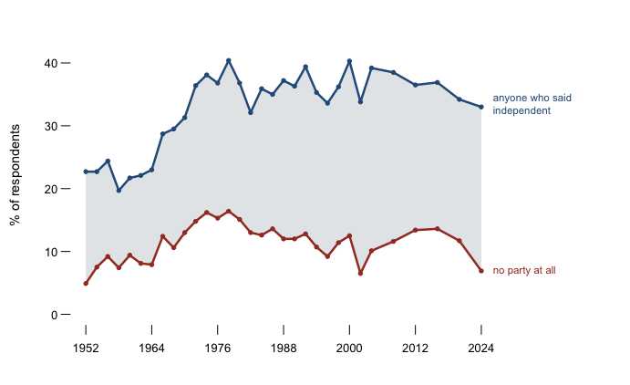

**Figure 1. The share of independents, 1952–2024, under two definitions.** Two lines on a time axis, because the claim is a claim about change and the argument is the distance between the lines. The shaded band is that disagreement: every point inside it is a person whose classification depends on a decision nobody states. Hovering breaks the band into leaning Democrats, pure independents and leaning Republicans. In 2024 the two definitions differ by 26.1 points.

| Year | Respondents | No party at all | Anyone who said independent | Gap |
| --- | --- | --- | --- | --- |
| 1952 | 1,689 | 4.9% | 22.7% | 17.8 pts |
| 1972 | 2,695 | 14.8% | 36.4% | 21.6 pts |
| 1992 | 2,470 | 12.8% | 39.4% | 26.6 pts |
| 2012 | 5,890 | 13.4% | 36.5% | 23.1 pts |
| 2024 | 5,483 | 6.9% | 33.0% | 26.1 pts |

The decision between them is not arbitrary, because leaners can be watched rather than argued about. Here is how each of the seven groups voted for president, across every year in which both questions were asked.

| Category | Respondents | Voted Democratic | Loyalty to nearer party |
| --- | --- | --- | --- |
| Strong Democrat | 8,556 | 95.3% | 95.3% |
| Weak Democrat | 5,531 | 78.4% | 78.4% |
| Independent-Democrat | 3,815 | 87.4% | 87.4% |
| Independent-Independent | 2,368 | 47.7% | 52.3% |
| Independent-Republican | 3,586 | 13.7% | 86.3% |
| Weak Republican | 4,240 | 16.1% | 83.9% |
| Strong Republican | 6,198 | 2.9% | 97.1% |

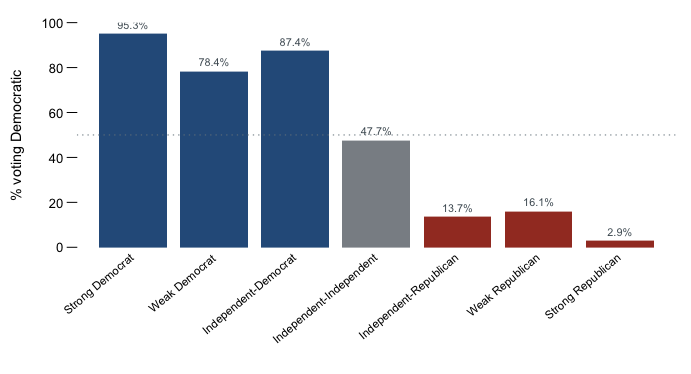

**Leaning Democrats vote Democratic 87.4% of the time. Weak Democrats vote Democratic 78.4% of the time.** The same holds on the other side: leaning Republicans are loyal 86.3% of the time against 83.9% for weak Republicans. People who decline to call themselves partisans are *more* reliable partisan voters than people who accept the label. Whatever the leaners are, they are not undecided, and they are not up for grabs.

And look at the middle bar. Respondents who claimed no party at all split 47.7% to 52.3% — the only group in the file that behaves the way the word *independent* is supposed to describe. That group is 6.9% of 2024 respondents, not a third.

Now put the convenience column beside a do-it-yourself count.

| Seven point category | Share | The file files them under |
| --- | --- | --- |
| Strong Democrat | 20.8% | Democrat |
| Weak Democrat | 18.5% | Democrat |
| Independent-Democrat | 11.9% | Democrat |
| Independent-Independent | 11.6% | Independent |
| Independent-Republican | 10.4% | Republican |
| Weak Republican | 13.0% | Republican |
| Strong Republican | 13.8% | Republican |

Reach for `VCF0303` because it is tidier, and you will report an independent share of **11.6%**. Do the collapse yourself from the seven-point column, keeping everyone who said the word, and you may report **33.9%**. The difference is not an error in either direction. It is a definition, made by someone else, in a note.

## What this brief cannot tell you

The vote comparison pools every study year, so it shows that leaners have behaved like partisans on average since 1952, not that they have always done so or do so equally today. Party loyalty has risen across all seven groups; a year-by-year version would show the leaners’ loyalty rising with everyone else’s.

Nothing here is weighted. `VCF0009z` is in the file and deliberately unused, so every percentage describes the people ANES interviewed rather than the country. For comparisons between groups inside one survey this matters less than it would for a level, but it is a choice, and it was made.

The brief takes no position on what partisanship *is* — whether it is a running tally of evaluations or a social identity acquired early and rarely revised.[^2] That argument is real and long, and none of it can be settled by noticing that a column has three questions in it.

Finally: leaners voting like partisans is evidence that they are partisans, not proof. A person can vote for the same party every time and still refuse the label, and refusing the label may be the more interesting fact about them. The data can tell you what they did. It cannot tell you what to call them.

## What you should have learned

- The share of independents in the 2024 ANES is 6.9% or 33.0%, depending on one coding decision about leaners that headline numbers never state.
- `VCF0301` is not a scale but the record of a branching interview, and the fact that categories 3 and 5 came from a different branch lives in the codebook, not the data.
- Leaners vote like partisans: leaning Democrats are loyal 87.4% of the time against 78.4% for weak Democrats, and leaning Republicans 86.3% against 83.9%.
- The only group that behaves like the word *independent* — splitting 47.7% to 52.3% — claimed no party at all, and it is 6.9% of the 2024 study.
- The file’s own convenience column, `VCF0303`, resolves the leaner question silently; using it instead of your own collapse moves the reported share from 33.9% to 11.6%.

## Extensions

None of these is answered above, and every one can be answered from the tables the Sources section hands over.

- `independents.csv` reports the share of independents three ways for every year, plus the `spread` between them. Sort by `spread` and find when the definitions disagreed most. Pick the coding you would use, then argue for it.
- `leaners.csv` gives each category a `pct_voted_democratic` and a `loyalty`. Compare the leaners against the weak partisans on both columns. Do leaners behave like independents or like partisans?
- `sevenpoint.csv` keeps all seven categories by year. Follow `pure_ind` across the whole series. Is the rise of the independent voter visible in this column at all?
- `collapse.csv` shows where the file itself puts each category, with each one’s `share`. Find the decision you disagree with, and work out how much the headline number moves if you change it.

Two stretch ideas point past the spreadsheet. Gallup publishes its own party-affiliation series (https://news.gallup.com/poll/15370/party-affiliation.aspx), asked of adults rather than of ANES respondents; find its latest independent share and decide which of Figure 1’s two lines it is nearer to, and why. And in the states that register voters by party, registration files count the unaffiliated directly — compare a state’s unaffiliated share against both lines and ask which definition registration is closest to.

## Sources

**Data**

- American National Election Studies. *ANES Time Series Cumulative Data File (1948–2024)*, version of 5 February 2026. Ann Arbor, MI and Palo Alto, CA: University of Michigan and Stanford University. https://electionstudies.org/data-center/anes-time-series-cumulative-data-file/
- ANES. *Time Series Cumulative Data File Codebook*, same release. The branching wording of `VCF0301` and the collapse note for `VCF0303` are quoted from it directly.

**Academic literature**

- Campbell, Angus, Philip E. Converse, Warren E. Miller and Donald E. Stokes (1960). *The American Voter.* John Wiley & Sons. The seven-point measure begins here.
- Keith, Bruce E., David B. Magleby, Candice J. Nelson, Elizabeth Orr, Mark C. Westlye and Raymond E. Wolfinger (1992). *The Myth of the Independent Voter.* University of California Press. The book-length version of Figure 2. https://www.ucpress.edu/book/9780520077201/the-myth-of-the-independent-voter
- Petrocik, John R. (2009). “Measuring party support: Leaners are not independents.” *Electoral Studies* 28(4): 562–572. https://doi.org/10.1016/j.electstud.2009.05.022
- Fiorina, Morris P. (1981). *Retrospective Voting in American National Elections.* Yale University Press. Partisanship as a running tally. https://yalebooks.yale.edu/book/9780300025576/retrospective-voting-in-american-national-elections/
- Green, Donald, Bradley Palmquist and Eric Schickler (2002). *Partisan Hearts and Minds.* Yale University Press. Partisanship as a social identity. https://yalebooks.yale.edu/book/9780300101560/partisan-hearts-and-minds/
- Gallup. *Party Affiliation*, trend since 2004. https://news.gallup.com/poll/15370/party-affiliation.aspx

**The data itself**

Every figure above is drawn from these tables. They are plain CSV, they open in a spreadsheet, and they are yours to take further.

`collapse.csv`, `independents.csv`, `leaners.csv`, `sevenpoint.csv`

[^1]: The book-length version of this argument, on the same survey, is Bruce E. Keith et al., *The Myth of the Independent Voter* (Berkeley: University of California Press, 1992), https://www.ucpress.edu/book/9780520077201/the-myth-of-the-independent-voter.
[^2]: The running-tally view is Morris P. Fiorina, *Retrospective Voting in American National Elections* (New Haven: Yale University Press, 1981), https://yalebooks.yale.edu/book/9780300025576/retrospective-voting-in-american-national-elections/; the social-identity view is Donald Green, Bradley Palmquist and Eric Schickler, *Partisan Hearts and Minds* (New Haven: Yale University Press, 2002), https://yalebooks.yale.edu/book/9780300101560/partisan-hearts-and-minds/.